# Report

## Task 1

$$f(x_1, x_2) = (x_1 + x_2)^2$$ Partial dependence: $$ g^{PD}_1(z)=\mathbb{E}_{X_{−1}}f(X_{1|=z}) $$ $$ g^{PD}_1(z)=\mathbb{E}_{X_2}(z + X_2)^2 $$ $$ g^{PD}_1(z)=\mathbb{E}_{X_2}(z^2 + X_2^2 +2zX_2) $$ $$ g^{PD}_1(z)=z^2 + \mathbb{E}_{X_2}(X_2^2) $$ $$ g^{PD}_1(z)=z^2 + \frac{1}{3} $$

Marginal effects: $$g^{MP}_1(z)=\mathbb{E}_{X_{−1}|x_1=z}f(x_{1|=z})=\mathbb{E}_{X_{2}|x_1=x_2=z} (z^2+x_2^2 + 2zx_2) = z^2 + 2z^2 + z^2 = 4z^2$$

Accumulated Local Effects: $$ g^{AL}_1(z)=∫_{-1}^z \left(E_{X_{−1}|x_1=v}\frac{∂f(x)}{∂x_1} \right) dv $$ $$ g^{AL}_1(z)=∫_{-1}^z \left(E_{X_{2}|x_1=x_2=v}\frac{∂(x_1 + x_2)^2}{∂x_1} \right) dv $$ $$ g^{AL}_1(z)=∫_{-1}^z \left(E_{X_{2}|x_1=x_2=v} 2x_1 + 2x_2 \right) dv $$ $$ g^{AL}_1(z)=∫_{-1}^z 4v dv = 2z^2 - 2$$

## Task 2

I look at the observations as in the previous homework and variables that were the most important for them. I used XGBoost model and SVM model for comparison.

These are the Ceteris Paribus plots for two observations:

[figure not shown]

As one can see, the profiles are very different for different variables:

We can take a look at PDP plot:

[figure not shown]

When averages, most of the variables does not seem to have big influence on prediction, apart from variable 0. This may suggest that variable 0 is important for a lot of observations, having big impact on prediction, while other variables are important only in parts of dataset and can have either positive or negative impact, which averages out to constant.

If we look at the same plot for the SVM model we can notice that it is very similar. It is more smooth, but the trend is the same.

[figure not shown]

I implemented the CP and PDP methods myself, as well, here are the plots obtained using them, for the XGBoost model.

[figure not shown]

# Appendix

## Imports and data loading

```python
!pip install -U imbalanced-learn
!pip install xgboost
!pip install dalex
!pip install alibi
```

```python
import dalex as dx
import xgboost
import alibi

import sklearn

import pandas as pd
import numpy as np

import warnings
warnings.filterwarnings("ignore")
```

```python
from imblearn.datasets import fetch_datasets

imblearn_datasets = fetch_datasets()
```

```python
from collections import Counter

yeast_me2 = imblearn_datasets['yeast_me2']
print("dataset shape: ", yeast_me2.data.shape)
smaller, bigger = list(sorted(Counter(yeast_me2.target).values()))
print(f"{bigger=}, {smaller=}, imbalance ratio={bigger/smaller:.2f}")
```

```
dataset shape:  (1484, 8)
bigger=1433, smaller=51, imbalance ratio=28.10
```

```python
from sklearn.model_selection import train_test_split
from imblearn.over_sampling import SMOTE

X, y = yeast_me2.data, yeast_me2.target
y[y == -1] = 0

X_train, X_test, y_train, y_test = train_test_split(X, y, test_size=0.33, random_state=42)

X_resampled, y_resampled = SMOTE().fit_resample(X_train, y_train)
```

```python
from sklearn.metrics import accuracy_score, confusion_matrix, f1_score, roc_auc_score, recall_score, precision_score

def evaluate_method(method_name, y_test, y_eval, verbose=False):
    results = {
        func.__name__: func(y_test, y_eval) for func in [
            accuracy_score,
            confusion_matrix,
            f1_score,
            roc_auc_score,
            recall_score,
            precision_score
        ]
    }

    if verbose:
        print(method_name, ' results:')
        for func_name, score in results.items():
            print("\t", func_name, ": ", score)

    return results
```

## XGBoost

```python
from xgboost import XGBClassifier

XGBoost_model = XGBClassifier().fit(X_resampled, y_resampled)
y_eval_XGBoost = XGBoost_model.predict(X_test)
results_XGBoost = evaluate_method('XGBoost with SMOTE', y_test, y_eval_XGBoost)
```

## Ceteris Paribus for XGBoost

```python
observation_to_explain_indices = [46, 221]
```

```python
def xgboost_classifier(model, data):
    return model.predict_proba(data)[:, 1]

explainer = dx.Explainer(XGBoost_model, X_test, y_test, predict_function=xgboost_classifier)
```

```
Preparation of a new explainer is initiated

  -> data              : numpy.ndarray converted to pandas.DataFrame. Columns are set as string numbers.
  -> data              : 490 rows 8 cols
  -> target variable   : 490 values
  -> model_class       : xgboost.sklearn.XGBClassifier (default)
  -> label             : Not specified, model's class short name will be used. (default)
  -> predict function  : <function xgboost_classifier at 0x7e5335763130> will be used
  -> predict function  : Accepts pandas.DataFrame and numpy.ndarray.
  -> predicted values  : min = 7.29e-06, mean = 0.0526, max = 0.999
  -> model type        : classification will be used (default)
  -> residual function : difference between y and yhat (default)
  -> residuals         : min = -0.998, mean = -0.0281, max = 1.0
  -> model_info        : package xgboost

A new explainer has been created!
```

```python
explainer.model_performance()
```

|  | recall | precision | f1 | accuracy | auc |
| --- | --- | --- | --- | --- | --- |
| XGBClassifier | 0.583333 | 0.333333 | 0.424242 | 0.961224 | 0.909693 |

```python
explainer.model_parts().result
```

|  | variable | dropout_loss | label |
| --- | --- | --- | --- |
| 0 | 6 | 0.084257 | XGBClassifier |
| 1 | 3 | 0.086611 | XGBClassifier |
| 2 | 5 | 0.090307 | XGBClassifier |
| 3 | _full_model_ | 0.090307 | XGBClassifier |
| 4 | 4 | 0.090307 | XGBClassifier |
| 5 | 7 | 0.090795 | XGBClassifier |
| 6 | 1 | 0.102301 | XGBClassifier |
| 7 | 2 | 0.190010 | XGBClassifier |
| 8 | 0 | 0.327563 | XGBClassifier |
| 9 | _baseline_ | 0.466641 | XGBClassifier |

```python
cp = explainer.predict_profile(new_observation=X[observation_to_explain_indices])
```

```python
cp.plot(variables=['6', '3', '5', '0', '1'])
```

[interactive chart not shown]

```python
pdp = explainer.model_profile()
```

```python
pdp.plot(variables=['6', '3', '5', '0', '1'])
```

[interactive chart not shown]

## PDP for SVM

```python
from sklearn.svm import SVC

svm = SVC(probability=True).fit(X_resampled, y_resampled)

exp_svm = dx.Explainer(svm, X_test, label="SVM", verbose=False)
```

```python
pdp_svm = exp_svm.model_profile()
```

```python
pdp_svm.plot(variables=['6', '3', '5', '0', '1'])
```

[interactive chart not shown]

## Ceteris Paribus and PDP implementation

```python
import matplotlib.pyplot as plt

def ceteris_paribus(
    model,
    dataset,
    observations,
    variables,
    num_samples = 20
):

    fig, axes = plt.subplots(
        nrows=len(variables),
        ncols=1,
        squeeze=True,
        layout="constrained",
        figsize=(10, len(variables) * 4)
    )

    if not isinstance(axes, list):
        axes = [axes]

    fig.suptitle("Ceteris paribus")

    for ax, variable in zip(axes, variables):
        # Single plot.
        ax.set_title(f"Variable {variable}")
        # Calculate range appropriate for variable.
        range_min = dataset[:, variable].min()
        range_max = dataset[:, variable].max()

        inputs = np.linspace(range_min, range_max, num_samples)

        for observation in observations:
            # Single line on the plot.
            ax.plot([observation[variable]], [model(observation)], marker="o", markersize=5, color='blue')
            x = np.copy(observation)
            outputs = []
            for variable_value in inputs:
                x[variable] = variable_value
                outputs.append(model(x))

            ax.plot(inputs, outputs, color='blue', alpha=0.4, label=f'observation {observation}')

    plt.show()
```

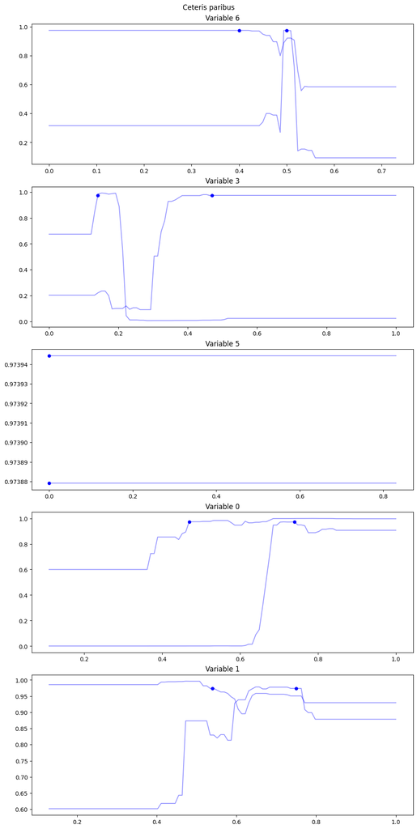

```python
ceteris_paribus(
    model=lambda x: XGBoost_model.predict_proba([x])[:, 1],
    dataset=X,
    observations=X[observation_to_explain_indices],
    variables=[6, 3, 5, 0, 1],
    num_samples=100
)
```

```python
def partial_dependence(
    model,
    dataset,
    variables,
    num_samples_variable=20,
    num_samples_observation=20
):
    fig, axes = plt.subplots(
        nrows=len(variables),
        ncols=1,
        squeeze=True,
        layout="constrained",
        figsize=(10, len(variables) * 4)
    )

    if not isinstance(axes, list):
        axes = [axes]

    fig.suptitle("Partial dependence")

    observations = dataset[np.random.choice(range(len(dataset)), num_samples_observation, replace=False)]

    for ax, variable in zip(axes, variables):
        # Single plot.
        ax.set_title(f"Variable {variable}")
        # Calculate range appropriate for variable.
        range_min = dataset[:, variable].min()
        range_max = dataset[:, variable].max()

        inputs = np.linspace(range_min, range_max, num_samples_variable)
        outputs = np.zeros((num_samples_observation, num_samples_variable))

        for i, observation in enumerate(observations):
            # Single line on the plot.
            x = np.copy(observation)

            for j, variable_value in enumerate(inputs):
                x[variable] = variable_value
                outputs[i, j] = model(x)

            ax.plot(inputs, outputs[i, :], color='blue', alpha=0.3)

        ax.plot(inputs, outputs.mean(axis=0), color='red')

    plt.show()
```

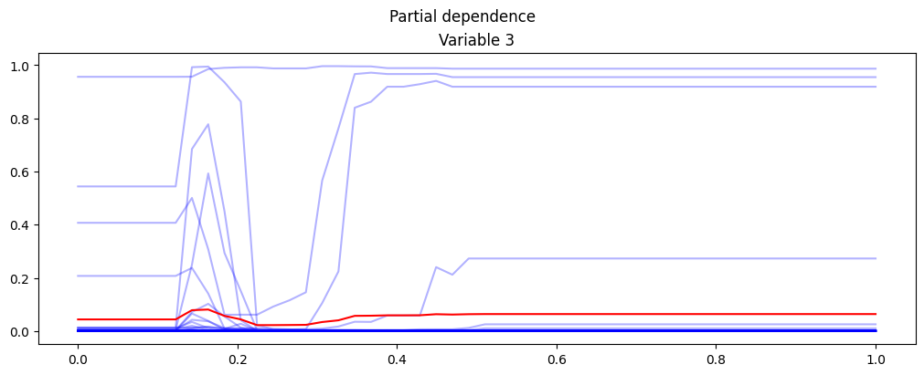

```python
partial_dependence(
    model=lambda x: XGBoost_model.predict_proba([x])[:, 1],
    dataset=X,
    variables=[3],
    num_samples_variable=50,
    num_samples_observation=50
)
```